# Two Sample Testing

### Two Sample Tests

#### Z-Tests

```python
import numpy as np
import pandas as pd
import matplotlib.pyplot as plt
import seaborn as sns
from statsmodels.stats import weightstats
import scipy.stats as stats
```

Here, we have no mue values

```python
df = pd.read_csv('C:\\Users\\varroju\\OneDrive - DXC Production\\Documents\\My\\My Learning\\DXC - Data Science\\Training\\Hypothesis Testing\\Two Sample Test\\Two+Machines.csv')
```

```python
df
```

|  | Volume | Machine |
| --- | --- | --- |
| 0 | 154.27 | Machine 1 |
| 1 | 150.03 | Machine 1 |
| 2 | 151.14 | Machine 1 |
| 3 | 145.47 | Machine 1 |
| 4 | 149.71 | Machine 1 |
| ... | ... | ... |
| 195 | 152.05 | Machine 2 |
| 196 | 151.41 | Machine 2 |
| 197 | 153.76 | Machine 2 |
| 198 | 150.75 | Machine 2 |
| 199 | 147.80 | Machine 2 |

200 rows × 2 columns

```python
df.info()
```

```
<class 'pandas.core.frame.DataFrame'>
RangeIndex: 200 entries, 0 to 199
Data columns (total 2 columns):
 #   Column   Non-Null Count  Dtype
---  ------   --------------  -----
 0   Volume   200 non-null    float64
 1   Machine  200 non-null    object
dtypes: float64(1), object(1)
memory usage: 3.2+ KB
```

```python
df.head()
```

|  | Volume | Machine |
| --- | --- | --- |
| 0 | 154.27 | Machine 1 |
| 1 | 150.03 | Machine 1 |
| 2 | 151.14 | Machine 1 |
| 3 | 145.47 | Machine 1 |
| 4 | 149.71 | Machine 1 |

```python
df.describe()
```

|  | Volume |
| --- | --- |
| count | 200.000000 |
| mean | 151.538350 |
| std | 2.180823 |
| min | 145.440000 |
| 25% | 150.015000 |
| 50% | 151.515000 |
| 75% | 153.110000 |
| max | 156.230000 |

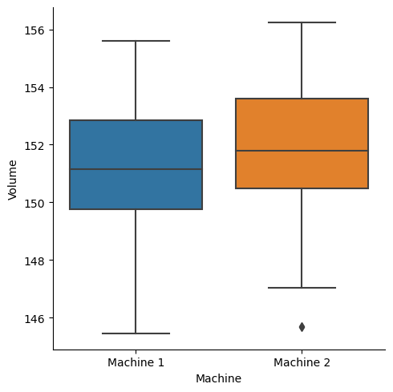

```python
sns.catplot(data= df, x='Machine', y='Volume' , kind ='box')
```

```python
m1 = df[df['Machine'] == 'Machine 1']['Volume']
m1
```

```
0     154.27
1     150.03
2     151.14
3     145.47
4     149.71
       ...
95    152.85
96    151.03
97    152.08
98    152.29
99    148.18
Name: Volume, Length: 100, dtype: float64
```

```python
m2 = df[df['Machine'] == 'Machine 2']['Volume']
m2
```

```
100    152.87
101    154.68
102    154.21
103    155.91
104    152.63
        ...
195    152.05
196    151.41
197    153.76
198    150.75
199    147.80
Name: Volume, Length: 100, dtype: float64
```

```python
weightstats.ztest(m1,m2) # Z value = -2.189406040190184;p Value = 0.028567341032618248; p < 0.05(alpha): Reject Null Hypothesis
```

```
(-2.189406040190184, 0.028567341032618248)
```

```python
# T- Test
```

```python
stats.ttest_ind(m1,m2,equal_var=True)
# Z V8alue = -2.189406040190184;p Value =0.029736299645472124; p < 0.05(alpha): Reject Null Hypothesis
```

```
Ttest_indResult(statistic=-2.189406040190184, pvalue=0.029736299645472124)
```

#### Two Sampling Z Test Tips Dataset

```python
import numpy as np
import pandas as pd
import matplotlib.pyplot as plt
import seaborn as sns
from statsmodels.stats import weightstats
import scipy.stats as stats
```

```python
sns.get_dataset_names()
```

```
['anagrams',
 'anscombe',
 'attention',
 'brain_networks',
 'car_crashes',
 'diamonds',
 'dots',
 'dowjones',
 'exercise',
 'flights',
 'fmri',
 'geyser',
 'glue',
 'healthexp',
 'iris',
 'mpg',
 'penguins',
 'planets',
 'seaice',
 'taxis',
 'tips',
 'titanic']
```

```python
tips = sns.load_dataset('tips')
```

```python
tips.head()
```

|  | total_bill | tip | sex | smoker | day | time | size |
| --- | --- | --- | --- | --- | --- | --- | --- |
| 0 | 16.99 | 1.01 | Female | No | Sun | Dinner | 2 |
| 1 | 10.34 | 1.66 | Male | No | Sun | Dinner | 3 |
| 2 | 21.01 | 3.50 | Male | No | Sun | Dinner | 3 |
| 3 | 23.68 | 3.31 | Male | No | Sun | Dinner | 2 |
| 4 | 24.59 | 3.61 | Female | No | Sun | Dinner | 4 |

```python
tips.info()
```

```
<class 'pandas.core.frame.DataFrame'>
RangeIndex: 244 entries, 0 to 243
Data columns (total 7 columns):
 #   Column      Non-Null Count  Dtype
---  ------      --------------  -----
 0   total_bill  244 non-null    float64
 1   tip         244 non-null    float64
 2   sex         244 non-null    category
 3   smoker      244 non-null    category
 4   day         244 non-null    category
 5   time        244 non-null    category
 6   size        244 non-null    int64
dtypes: category(4), float64(2), int64(1)
memory usage: 7.4 KB
```

```python
tips.describe()    # Sample Size is >30 . So we can go for Z test
```

|  | total_bill | tip | size |
| --- | --- | --- | --- |
| count | 244.000000 | 244.000000 | 244.000000 |
| mean | 19.785943 | 2.998279 | 2.569672 |
| std | 8.902412 | 1.383638 | 0.951100 |
| min | 3.070000 | 1.000000 | 1.000000 |
| 25% | 13.347500 | 2.000000 | 2.000000 |
| 50% | 17.795000 | 2.900000 | 2.000000 |
| 75% | 24.127500 | 3.562500 | 3.000000 |
| max | 50.810000 | 10.000000 | 6.000000 |

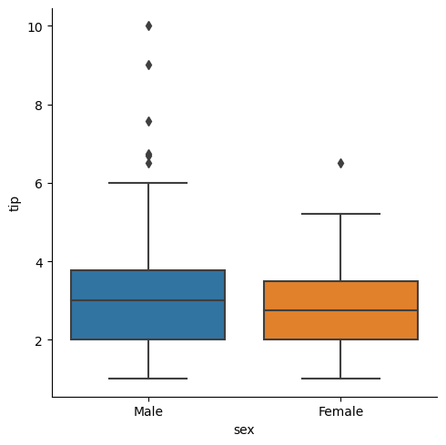

```python
sns.catplot(data=tips, x='sex', y='tip', kind ='box' )
```

```python
# Whether there is a significant difference in the tips given by male or female.
tm = tips[tips['sex'] == 'Male'] ['tip']
tm
```

```
1      1.66
2      3.50
3      3.31
5      4.71
6      2.00
       ...
236    1.00
237    1.17
239    5.92
241    2.00
242    1.75
Name: tip, Length: 157, dtype: float64
```

```python
tf = tips[tips['sex'] == 'Female'] ['tip']
tf
```

```
0      1.01
4      3.61
11     5.00
14     3.02
16     1.67
       ...
226    2.00
229    2.88
238    4.67
240    2.00
243    3.00
Name: tip, Length: 87, dtype: float64
```

```python
weightstats.ztest(tm,tf) # z=1.3878597054212687;p=0.1651797698624794;p > alpha(0.05); Fail to Reject Null Hypothesis.
```

```
(1.3878597054212687, 0.1651797698624794)
```

```python
# Lunch/Dinner
# whether there is any significant difference in the tips given during the lunch or during the dinner,
tl = tips[tips['time'] == 'Lunch'] ['tip']
tl
```

```
77     4.00
78     3.00
79     2.71
80     3.00
81     3.40
       ...
222    1.92
223    3.00
224    1.58
225    2.50
226    2.00
Name: tip, Length: 68, dtype: float64
```

```python
td = tips[tips['time'] == 'Dinner'] ['tip']
td
```

```
0      1.01
1      1.66
2      3.50
3      3.31
4      3.61
       ...
239    5.92
240    2.00
241    2.00
242    1.75
243    3.00
Name: tip, Length: 176, dtype: float64
```

```python
weightstats.ztest(tl,td) # z = -1.9062569301202392; p=0.05661687925222567; p> apha(0.05); Fail to Reject Null Hypothesis
```

```
(-1.9062569301202392, 0.05661687925222567)
```

### Two Sample t Test Using Python

```python
import numpy as np
import pandas as pd
import matplotlib.pyplot as plt
import seaborn as sns
from statsmodels.stats import weightstats
import scipy.stats as stats
```

```python
# Two sample t Test - Equal Variance
m1 = [150,151,152,152,154]
m2 = [156,155,158,155,154]
```

```python
stats.ttest_ind(m1, m2, equal_var=True) # tcal = -4.005551702879929; pvalue=0.0.003919295477128331; p < Apha(0.05); REJECTED
```

```
Ttest_indResult(statistic=-4.005551702879929, pvalue=0.003919295477128331)
```

```python
# Two sample t Test - Unequal Variance
m1 = [150,151,152,152,154]
m3 = [144,162,177,150,140]
```

```python
stats.ttest_ind(m1, m3, equal_var=False) # tcal-0.4146442144313621; pvalue=0.699289145758865);p > Apha(0.05); FAIL TO REJECT
```

```
Ttest_indResult(statistic=-0.4146442144313621, pvalue=0.699289145758865)
```

### Paired t Test Using Python

```python
import numpy as np
import pandas as pd
import matplotlib.pyplot as plt
import seaborn as sns
from statsmodels.stats import weightstats
import scipy.stats as stats
```

```python
bp_before = [120,122,143,100,109]
bp_after = [122,120,141,109,109]
```

```python
stats.ttest_rel(bp_before,bp_after) #t= -0.6864064729836442;p=0.5301776477578163; p> apha(0.05); Fail to Reject Null Hypothesis
```

```
TtestResult(statistic=-0.6864064729836442, pvalue=0.5301776477578163, df=4)
```

### Two Proportion Test Using Python

```python
import numpy as np
import pandas as pd
import matplotlib.pyplot as plt
import seaborn as sns
import statsmodels.stats.proportion as proportion
import scipy.stats as stats
```

```python
proportion.test_proportions_2indep(30,200,10,100)
```

```
<class 'statsmodels.stats.base.HolderTuple'>
statistic = 1.145433008876846
pvalue = 0.2520298311822946
compare = 'diff'
method = 'agresti-caffo'
diff = 0.04999999999999999
ratio = 1.4999999999999998
odds_ratio = 1.588235294117647
variance = 0.001586401953652147
alternative = 'two-sided'
value = 0
tuple = (1.145433008876846, 0.2520298311822946)
```

```python
proportion.test_proportions_2indep(30, 200, 10, 100, method='score')
```

```
<class 'statsmodels.stats.base.HolderTuple'>
statistic = 1.1989578808281796
pvalue = 0.2305443235633593
compare = 'diff'
method = 'score'
variance = 0.001739130434782609
alternative = 'two-sided'
prop1_null = 0.13333333333333333
prop2_null = 0.13333333333333333
tuple = (1.1989578808281796, 0.2305443235633593)
diff = 0.04999999999999999
ratio = 1.4999999999999998
odds_ratio = 1.588235294117647
value = 0
```

```python
#Z=1.1989578808281796;p=0.2305443235633593; p> apha(0.05); Fail to Reject Null Hypothesis
```

### Two Variances Test Using Python

```python
import numpy as np
import pandas as pd
import matplotlib.pyplot as plt
import seaborn as sns
import scipy.stats as stats
from scipy.stats import f
```

```python
F_cal  = 11/(1.1**2)
F_cal
```

```
9.09090909090909
```

```python
f.isf(0.05, 4, 7)  #Critical value of right
```

```
4.120311726897633
```

```python
f.isf(0.95, 4, 7)  #Critical value of left
```

```
0.1640901524729093
```

The Bartlett test is for equality of variances In this case, the variance might not exactly match with what we had in our question but this will be more or less similar to what we had.

```python
m1 = [150, 150, 151, 148,151, 152, 149, 150]
m2 = [135, 152, 154, 169, 157]
```

```python
np.std(m1)
```

```
1.165922381636102
```

```python
np.std(m2)
```

```
10.9288608738514
```

```python
stats.bartlett(m1,m2) # p < Apha(0.10); REJECTED NULL HYPOTHESIS
```

```
BartlettResult(statistic=19.105727631632714, pvalue=1.2367317910523616e-05)
```

```python
stats.levene(m1, m2) # p < Apha(0.10); REJECTED NULL HYPOTHESIS
```

```
LeveneResult(statistic=5.416245804750017, pvalue=0.040060452607943706)
```

Levene Test: Levene test is much stronger, much robust. This does not assume anything. So, whatever type of data you have, Levene test is a robust test. If it rejects the null hypothesis, that means you can truly believe that this hypothesis is rejected.

Bartlett Test: Bartlett Test has an assumption that these two samples are normally distributed and since these numbers are very small, you really cannot be very sure whether these are normally distributed or not.

???? - If you don't have any choice, go to Levene test and that will give you a much robust result. It will reject the null hypothesis only when this is really needs to be rejected and that's the reason, you will see that the P value of Levene test is much higher as compared to the Bartlett test.

SUMMARY: When you don't know about the data, when you don't know whether your data is normally distributed, these samples are normally distributed, ...go for the Levene test to check whether these two samples have equal variance or not.